# Introduction to Data Visualization in R

# Getting Started with Plotting in R

> *Above all else show the data.* – Edward Tufte

Visualizing data is one of the most important tasks in data analysis. This notebook will introduce you to basic plotting in R using ggplot2, the most popular visualization package in R.

```r
# Load the ggplot2 package
library(ggplot2)
```

## Your First Plot

Let’s start by creating a simple vector and plotting it. We’ll use the Fibonacci sequence as our example:

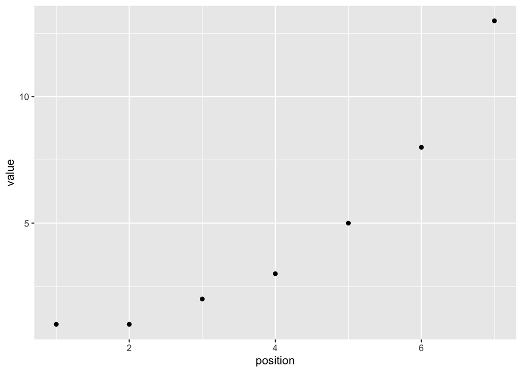

```r
# Create a data frame with the first 7 Fibonacci numbers
fibonacci_data <- data.frame(
  position = 1:7,
  value = c(1, 1, 2, 3, 5, 8, 13)
)

# Plot them
ggplot(fibonacci_data, aes(x = position, y = value)) +
  geom_point()
```

What ggplot2 has done here is plot the *values* on the vertical axis (y-axis) and the corresponding *position* on the horizontal axis (x-axis). Since the 4th element has a value of 3, we get a dot at location (4, 3).

**Understanding the syntax:** - `ggplot()` creates the plot object - `aes()` defines the aesthetic mappings (which variables go on which axes) - `geom_point()` adds points to the plot

## Customizing Titles and Labels

One of the first things you’ll want to do is add proper labels to your plot:

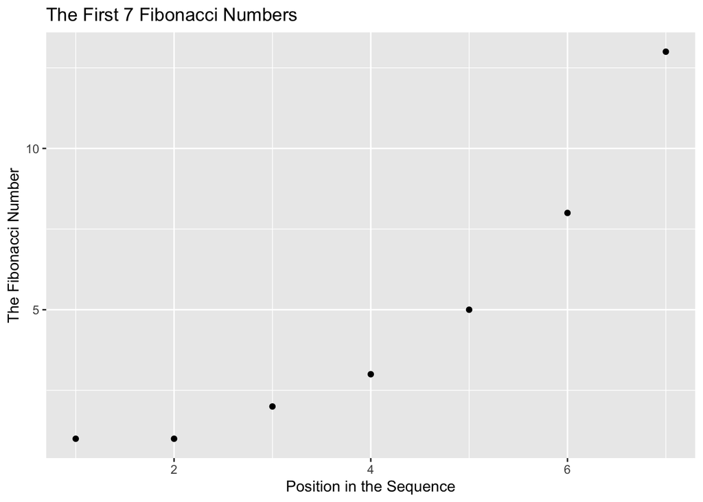

```r
ggplot(fibonacci_data, aes(x = position, y = value)) +
  geom_point() +
  labs(
    title = "The First 7 Fibonacci Numbers",
    x = "Position in the Sequence",
    y = "The Fibonacci Number"
  )
```

The `labs()` function lets you add: - `title`: The title of the plot - `x`: The x-axis label - `y`: The y-axis label

## Changing Plot Types

You can change how the data is displayed by using different `geom_` functions, e.g., geom_point() or geom_line()

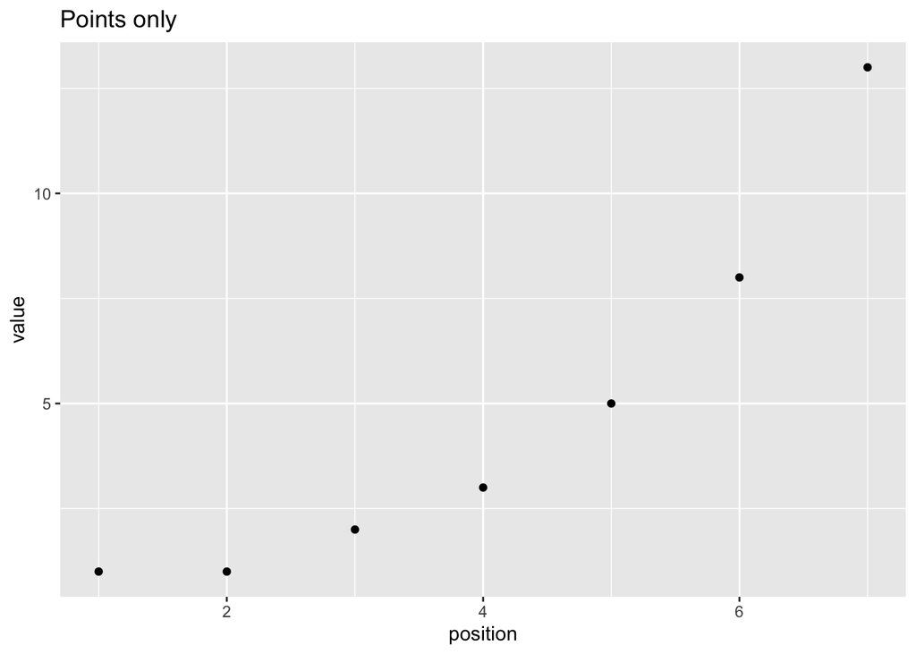

```r
# Points only
ggplot(fibonacci_data, aes(x = position, y = value)) +
  geom_point() +
  labs(title = "Points only")
```

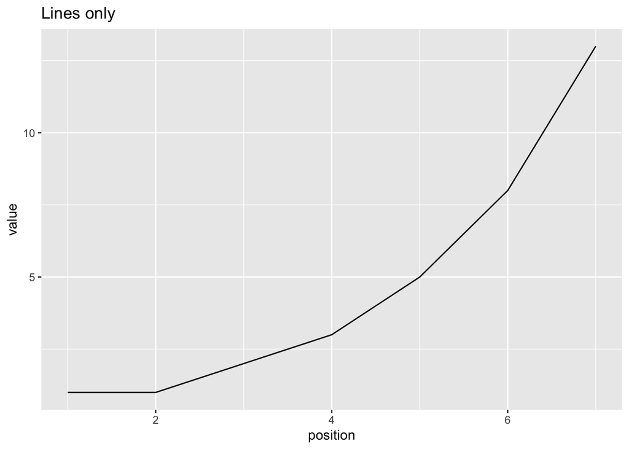

```r
# Lines only
ggplot(fibonacci_data, aes(x = position, y = value)) +
  geom_line() +
  labs(title = "Lines only")
```

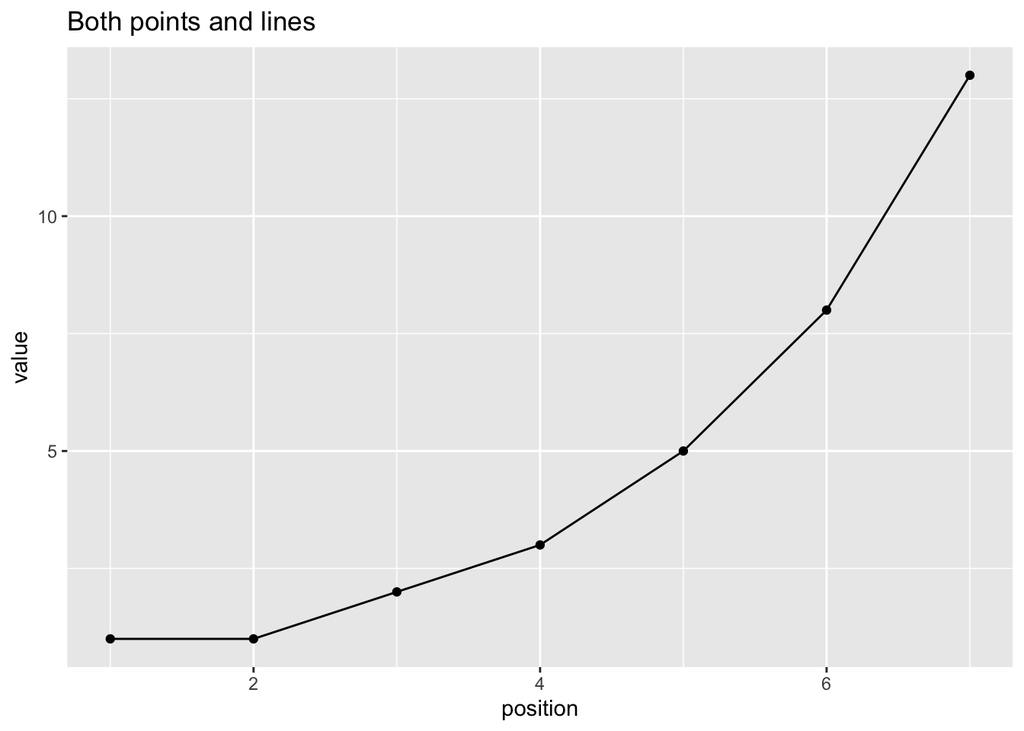

```r
# Both points and lines
ggplot(fibonacci_data, aes(x = position, y = value)) +
  geom_line() +
  geom_point() +
  labs(title = "Both points and lines")
```

## Customizing Plot Appearance

You can customize colors, point styles, line types, and more:

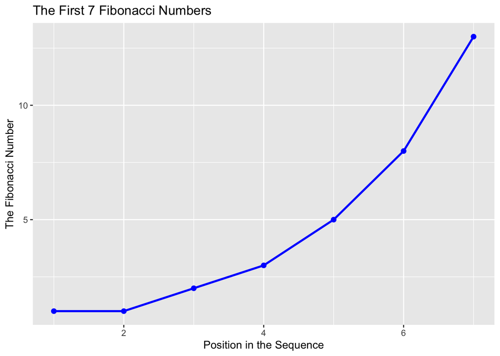

```r
ggplot(fibonacci_data, aes(x = position, y = value)) +
  geom_line(color = "blue", linewidth = 1) +
  geom_point(color = "blue", size = 2, shape = 19) +
  labs(
    title = "The First 7 Fibonacci Numbers",
    x = "Position in the Sequence",
    y = "The Fibonacci Number"
  )
```

Key customization options: - `color`: Color of points/lines - `size`: Size of points or line thickness - `shape`: Point shape (numbers 0-25 for different symbols) - `linewidth`: Width of lines

## Making the plot prettier

We can do lots of customizations now to make our plot even prettier!

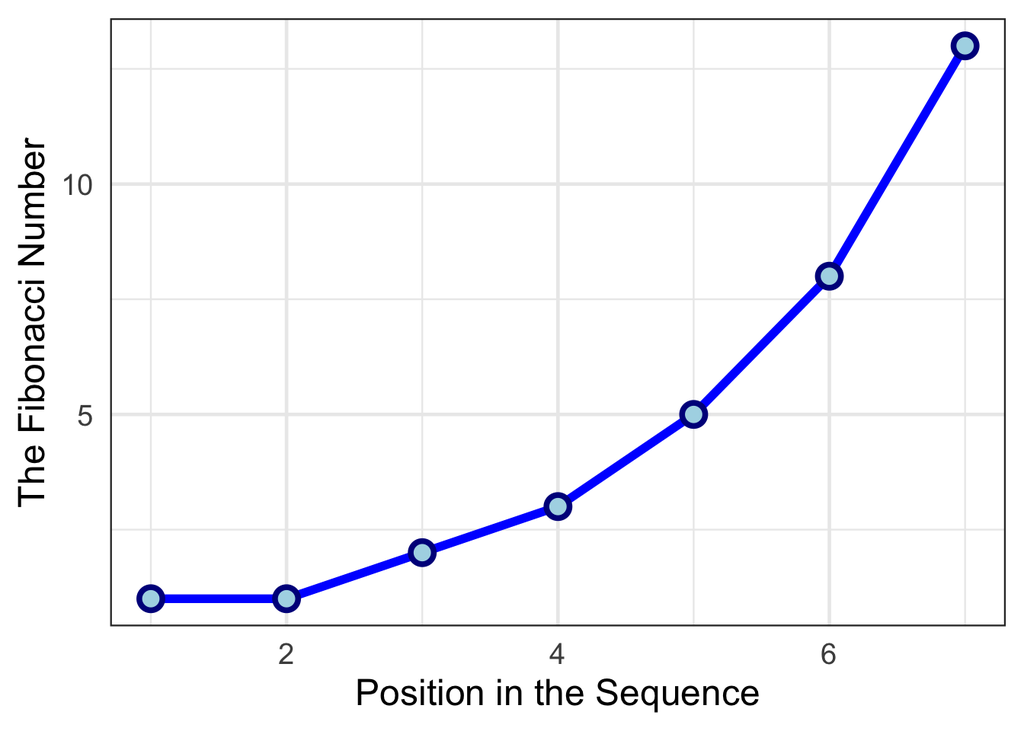

```r
ggplot(fibonacci_data, aes(x = position, y = value)) +
  geom_line(color = "blue", linewidth = 2) +
  geom_point(color = "darkblue", fill = "lightblue", size = 4, shape = 21, stroke = 2) +
  labs(
    x = "Position in the Sequence",
    y = "The Fibonacci Number"
  ) +
  theme_bw(base_size = 18) + #make it simple black-white theme and increase font size
theme(axis.ticks = element_blank()) #remove tick marks
```

## Histograms

Histograms are great for understanding the distribution of your data. Let’s create some simulated data:

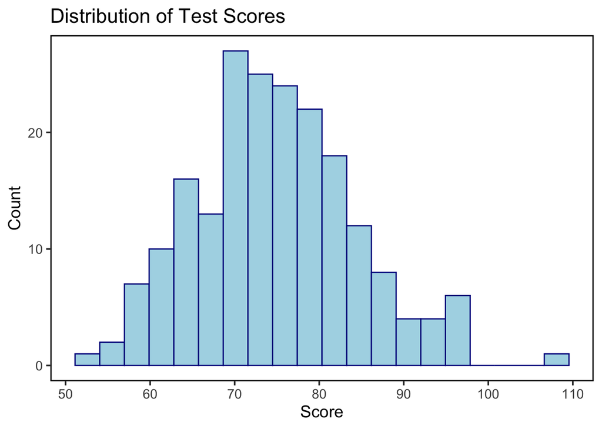

```r
# Simulate 200 test scores (normally distributed around 75)
set.seed(123)
scores_data <- data.frame(
  test_scores = rnorm(200, mean = 75, sd = 10)
)

# Draw a histogram
ggplot(scores_data, aes(x = test_scores)) +
  geom_histogram(fill = "lightblue", color = "darkblue", bins = 20) +
  labs(
    title = "Distribution of Test Scores",
    x = "Score",
    y = "Count"
  )+
  theme_bw(base_size = 14)+
  theme(panel.border = element_rect(color = "black", fill = NA, linewidth = 1),
        panel.grid = element_blank())  # Remove all grid lines
```

## Boxplots

Boxplots show the median, quartiles, and potential outliers in your data:

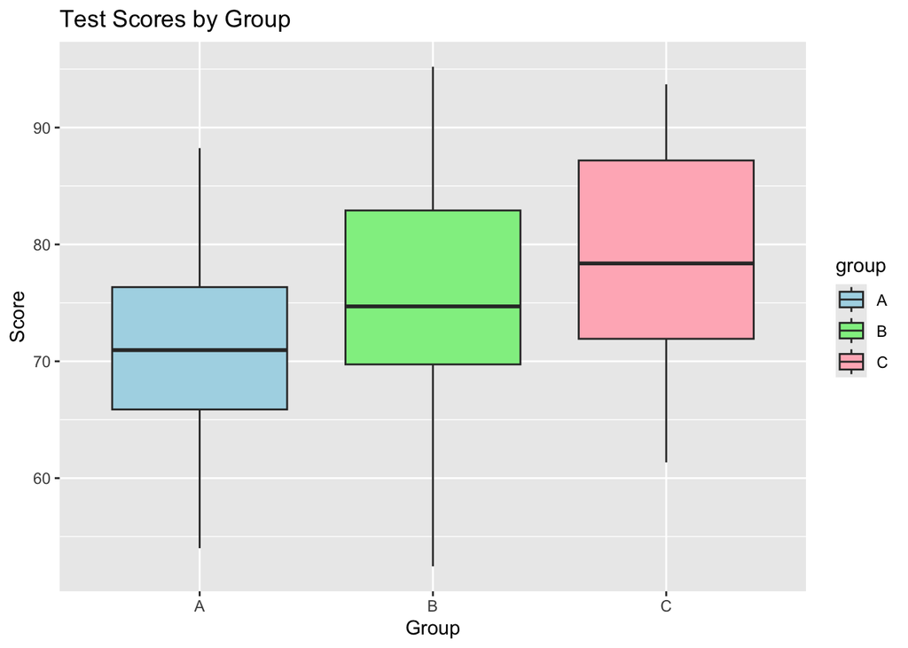

```r
# Create simulated data for three different groups
set.seed(456)
group_data <- data.frame(
  score = c(rnorm(50, mean = 70, sd = 8),
            rnorm(50, mean = 75, sd = 10),
            rnorm(50, mean = 80, sd = 9)),
  group = rep(c("A", "B", "C"), each = 50)
)

# Draw boxplots
ggplot(group_data, aes(x = group, y = score, fill = group)) +
  geom_boxplot() +
  scale_fill_manual(values = c("lightblue", "lightgreen", "lightpink")) +
  labs(
    title = "Test Scores by Group",
    x = "Group",
    y = "Score"
  ) +
  theme()
```

The thick line in each box shows the median. The box spans from the 25th to 75th percentile, and the whiskers extend to show the range of the data (excluding outliers).

## Scatterplots

Scatterplots show the relationship between two variables:

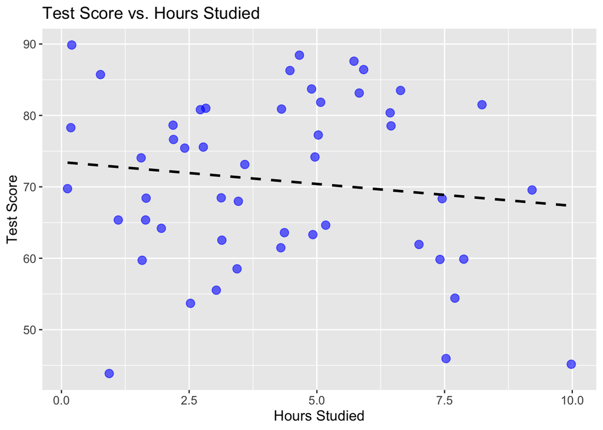

```r
# Simulate data: hours studied vs. test score
set.seed(789)
study_data <- data.frame(
  hours_studied = runif(50, min = 0, max = 10),
  test_score = 50 + 4 * runif(50, min = 0, max = 10) + rnorm(50, mean = 0, sd = 5)
)

# Draw scatterplot
ggplot(study_data, aes(x = hours_studied, y = test_score)) +
  geom_point(color = "blue", alpha = 0.6, size = 3) +
  geom_smooth(method = "lm", se = FALSE, color = "black",
              linetype = "dashed", linewidth = 1) +
  labs(
    title = "Test Score vs. Hours Studied",
    x = "Hours Studied",
    y = "Test Score"
  ) +
  theme(
    axis.title = element_text(size = 12),
    plot.title = element_text(size = 14),
    axis.text = element_text(size = 10)
  )
```

The `geom_smooth()` function adds a trend line to show the relationship.

## Bar Plots

Bar plots are useful for categorical data:

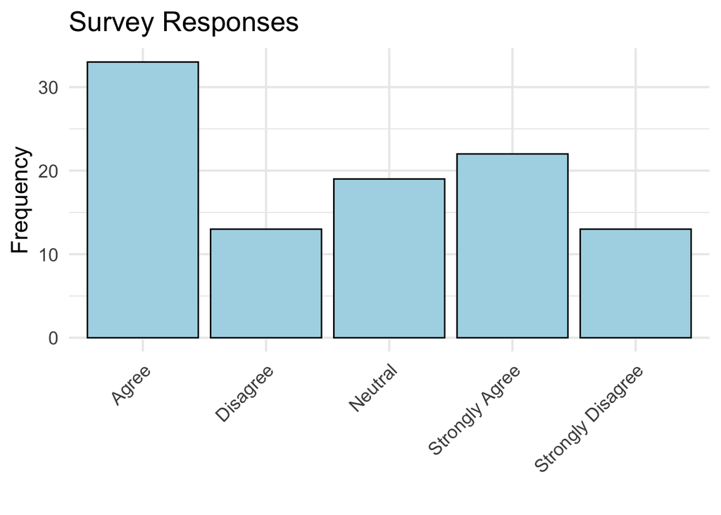

```r
# Simulate survey responses
set.seed(321)
survey_data <- data.frame(
  response = sample(c("Strongly Disagree", "Disagree", "Neutral",
                      "Agree", "Strongly Agree"),
                    100, replace = TRUE,
                    prob = c(0.1, 0.15, 0.2, 0.35, 0.2))
)

# Count frequencies and reorder
survey_counts <- as.data.frame(table(survey_data$response))
names(survey_counts) <- c("response", "freq")

# Draw bar plot
ggplot(survey_counts, aes(x = response, y = freq)) +
  geom_bar(stat = "identity", fill = "lightblue", color = "black") +
  labs(
    title = "Survey Responses",
    x = "",
    y = "Frequency"
  ) +
  theme_minimal(base_size = 16)+
  theme(axis.text.x = element_text(angle = 45, hjust = 1))
```

## Multiple Plots in One Figure

You can arrange multiple plots in a grid using the patchwork package:

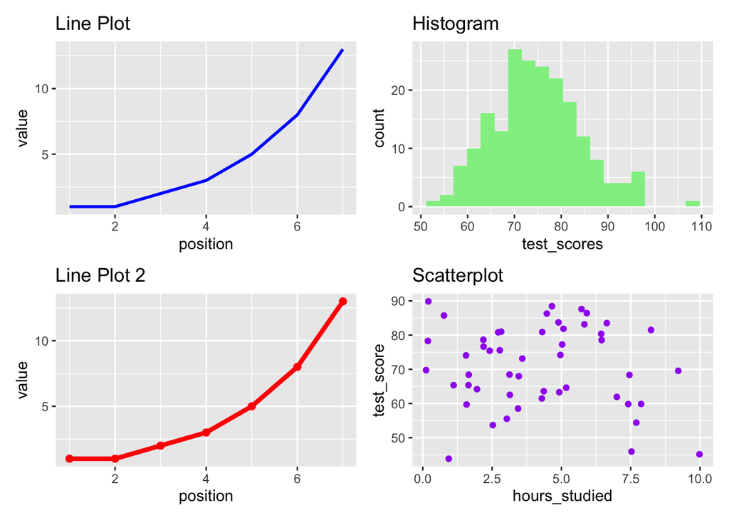

```r
# Install if needed: install.packages("patchwork")
library(patchwork)

# Create individual plots
p1 <- ggplot(fibonacci_data, aes(x = position, y = value)) +
  geom_line(color = "blue", linewidth = 1) +
  labs(title = "Line Plot")

p2 <- ggplot(scores_data, aes(x = test_scores)) +
  geom_histogram(fill = "lightgreen", bins = 20) +
  labs(title = "Histogram")

p3 <- ggplot(fibonacci_data, aes(x = position, y = value)) +
  geom_line(color = "red", linewidth = 1.5) +
  geom_point(color = "red", size = 2) +
  labs(title = "Line Plot 2")

p4 <- ggplot(study_data, aes(x = hours_studied, y = test_score)) +
  geom_point(color = "purple") +
  labs(title = "Scatterplot")

# Arrange in a 2x2 grid
(p1 | p2) / (p3 | p4)
```

## Key Takeaways

1. **ggplot()** is the foundation - it creates the plot object
2. **aes()** maps your data to visual properties (x, y, color, etc.)
3. **geom_*** functions add layers to your plot:
   - `geom_point()` for points
   - `geom_line()` for lines
   - `geom_histogram()` for histograms
   - `geom_boxplot()` for boxplots
   - `geom_bar()` for bar charts
4. **labs()** adds labels and titles
5. Customize appearance with color, size, and theme options
6. Build plots by adding layers with the `+` operator

**Why ggplot2?** It follows a consistent “grammar of graphics” that makes it easier to create complex visualizations as you advance in your R journey!